```python
import cv2
from matplotlib import pyplot as plt
import numpy as np

from mpl_toolkits.mplot3d import Axes3D  # noqa: F401 unused import
```

# Calibração Naïve

[figure not shown]

```python
# Pattern sides measurements
dX = 270 #mm
dY = 202 #mm
dZ = 1200 #mm

dx = 610 - 382 #pixels
dy = 767 - 594 #pixels

fx = dZ * (dx/dX)
fy = dZ * (dy/dY)

print('Focal Lenght (fx, fy): ({}, {})'.format(fx, fy))
```

```
Focal Lenght (fx, fy): (1013.3333333333334, 1027.7227722772277)
```

# Calibração pelo Octave

### Para calibração pelo octave um conjunto de 5 imagens foram geradas e inseridas na ferramenta.

A imagem abaixo ilustra a ferramenta identificando e extraindo pontos de referência para o cálculo dos parametros

[figure not shown]

### Após a definição dos eixos de coordenadas em todas as imagens o processo de calibração foi executado. Os resultados podem ser vistos nas imagens abaixo.

[figure not shown]

### Os parâmetros intrinsecos foram calculados e estão exibidos abaixo.

[figure not shown]

### Além dos parâmetros intrinsecos, também foi realizada a extração dos parâmetros extrinsecos de uma das imagens para construção de um modelo para verificar se os resultados estão consistentes.

[figure not shown]

## Construindo um modelo com os parâmetros obtidos

```python
# Auxiliar functions to homogenize coordinates

def to_homo(coord):
    return np.append(coord, 1)

def from_homo_2d(homo_coord):
    return np.array([ homo_coord[0]/homo_coord[2], homo_coord[1]/homo_coord[2] ])

def from_homo_3d(homo_coord):
    return np.array([ homo_coord[0]/homo_coord[3], homo_coord[1]/homo_coord[3], homo_coord[2]/homo_coord[3] ])
```

```python
# Camera model class

class CameraModel:
    def __init__(self, R, T, f, c):
        self.Mint = np.array([
            [f[0], 0, c[0], 0],
            [0, f[1], c[1], 0],
            [0,  0,  1, 0]
        ])
        self.f = f
        self.c = c
        self.R = R
        self.T = T
        self.Mext = np.zeros((4,4))
        self.Mext[0:3,0:3] = R
        self.Mext[0:3,3] = T
        self.Mext[3,3] = 1


    def to_camera_ref(self, world_point):
        t = world_point
        if t.shape[0] == 3: #homogenize
            t = to_homo(world_point)
        homo_res = self.Mext.dot(t)
        return from_homo_3d(homo_res)

    def project_world_point(self, world_point):
        t = world_point
        if t.shape[0] == 3: #homogenize
            t = to_homo(world_point)
        homo_res = self.Mint.dot(self.Mext).dot(t)
        return from_homo_2d(homo_res)

    def print_parameters(self):
        print('Focal length: {}'.format(self.f))
        print('Principal point: {}'.format(self.c))
        print('Translation vector: {}'.format(self.T))
        print('Rotation matrix:')
        print(self.R)
```

```python
## OCTAVE PARAMETERS ##
# Parameters obtained by calibration using octave are inserted below
f = np.array([1045.73, 1062.27])
c = np.array([639.50, 475.50])
R = np.array([
    [0.763311, 0.642743, -0.065099],
    [0.350098, -0.496238, -0.794468],
    [-0.542943, 0.583635, -0.603807]
])
T = np.array([ -217.467313, -51.212003, 457.262331])

octaveModel = CameraModel(R,T,f,c)
octaveModel.print_parameters()
```

```
Focal length: [1045.73 1062.27]
Principal point: [639.5 475.5]
Translation vector: [-217.467313  -51.212003  457.262331]
Rotation matrix:
[[ 0.763311  0.642743 -0.065099]
 [ 0.350098 -0.496238 -0.794468]
 [-0.542943  0.583635 -0.603807]]
```

```
(960, 1280, 3)
```

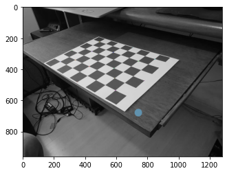

```python
# Reading test image (same image the extrinsic parameters were obtained)

input_image = cv2.imread('./inputs/AnInput01.tif', cv2.IMREAD_COLOR)
input_image = cv2.cvtColor(input_image, cv2.COLOR_BGR2RGB)
print(input_image.shape)
plt.imshow(input_image)
```

```python
# Data manually collected from our sample image
# Columns 0:3 -> point in World Coordinates (3D)
# Columns 3:5 -> point in Image Coordinates (2D)
world = [0,1,2]
image = [3, 4]

data = np.array([
    [240,30,0,594,535],
    [240,180,0,848,335],
    [30,180,0,493,224],
    [60,60,0,338,340],
    [120,60,0,427,382],
    [120,150,0,581,291],
    [210,150,0,742,348],
    [180,90,0,586,393],
    [60,120,0,444,285],
    [210,60,0,590,457],
    [30,30,0,241,351],
    [150,0,0,349,482],
    [0,90,0,316,280]
])
```

```
Sample 0  (240mm, 30 mm, 0  mm) -> 	 593.99, 530.78 	  594.00, 535.00 	  Err. (0.01, 4.22)
Sample 1  (240mm, 180mm, 0  mm) -> 	 836.59, 336.54 	  848.00, 335.00 	  Err. (11.41, -1.54)
Sample 2  (30 mm, 180mm, 0  mm) -> 	 488.44, 222.53 	  493.00, 224.00 	  Err. (4.56, 1.47)
Sample 3  (60 mm, 60 mm, 0  mm) -> 	 336.72, 336.90 	  338.00, 340.00 	  Err. (1.28, 3.10)
Sample 4  (120mm, 60 mm, 0  mm) -> 	 425.75, 378.57 	  427.00, 382.00 	  Err. (1.25, 3.43)
Sample 5  (120mm, 150mm, 0  mm) -> 	 575.28, 290.28 	  581.00, 291.00 	  Err. (5.72, 0.72)
Sample 6  (210mm, 150mm, 0  mm) -> 	 734.75, 346.96 	  742.00, 348.00 	  Err. (7.25, 1.04)
Sample 7  (180mm, 90 mm, 0  mm) -> 	 583.10, 390.80 	  586.00, 393.00 	  Err. (2.90, 2.20)
Sample 8  (60 mm, 120mm, 0  mm) -> 	 439.66, 282.78 	  444.00, 285.00 	  Err. (4.34, 2.22)
Sample 9  (210mm, 60 mm, 0  mm) -> 	 588.06, 454.53 	  590.00, 457.00 	  Err. (1.94, 2.47)
Sample 10 (30 mm, 30 mm, 0  mm) -> 	 239.70, 346.69 	  241.00, 351.00 	  Err. (1.30, 4.31)
Sample 11 (150mm, 0  mm, 0  mm) -> 	 352.98, 479.18 	  349.00, 482.00 	  Err. (-3.98, 2.82)
Sample 12 (0  mm, 90 mm, 0  mm) -> 	 312.07, 275.72 	  316.00, 280.00 	  Err. (3.93, 4.28)
```

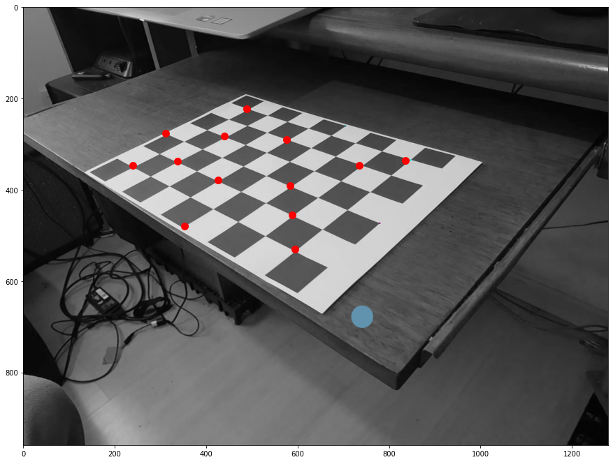

```python
proj_x = []
proj_y = []
for i in range(len(data)):
    wrld = data[i, world]
    img = data[i, image]
    proj = octaveModel.project_world_point(wrld)
    error = img - proj
    proj_x.append(proj[0])
    proj_y.append(proj[1])
    print('Sample {:<2} ({:<3}mm, {:<3}mm, {:<3}mm) -> \t {:.2f}, {:.2f} \t  {:.2f}, {:.2f} \t  Err. ({:.2f}, {:.2f}) '.format(
        i,
        wrld[0], wrld[1], wrld[2],
        proj[0], proj[1],
        img[0], img[1],
        error[0], error[1]
    ))


fig, ax = plt.subplots(figsize=(15,15))
# ax.imshow(input_image)
# fig, ax = plt.subplots()
x = range(300)
ax.imshow(input_image)
ax.scatter(proj_x, proj_y, s=100, c='r')
```

### Como pudemos ver acima a calibração apresentou resultados consistentes.

### Resultados melhores em termos de precisão poderiam ser obtidos. Para isso seria necessário a realização do processo de calibração com mais precisão no momento da definição dos eixos de coordenadas.

# Calibração utilizando o algoritmo do livro Trucco e Verri

[figure not shown]

A imagem acima ilustra a imagem tomada para a realização da calibração.

Importante notar que alterei o padrão para que ao invés de um plano os pontos de calibração pudessem ser extraidos das faces de um cubo.

Em amarelo os pontos coletados.

## Entradas e configuração

```python
# CONFIGURATION

# Since TRUCCO/VERRI algorithm assume that the image origin is in the center or the image
# original image coordinates should be translated to keep consistency
image_center_is_origin = True

force_rotation_matrix_orthogonal = True
```

```python
# INPUTS

# Define the center of the image
y0 = 1280/2
x0 = 960/2

# Data manually collected from our sample image
# Columns 0:3 -> point in World Coordinates (3D)
# Columns 3:5 -> point in Image Coordinates (2D)
world = [0,1,2]
image = [3, 4]

data = np.array([
    [0,0,0,485,895],
    [90,0,0, 628, 773],
    [0,0,30, 477, 845],
    [30,0,30, 532, 801],
    [150, 0, 60, 710, 602],
    [120, 0, 90, 670, 574],
    [60, 0, 90, 573, 648],
    [90, 0, 60, 624, 665],
    [0,0,120, 456, 666],
    [0,30, 0, 431, 854],
    [0, 60, 120, 343, 599],
    [0,60,60, 363, 722],
    [0, 120, 90, 256, 607],
    [0, 90,30, 327, 740],
    [30, 30, 120, 460, 589],
    [90, 90, 120, 464, 489],
    [60, 30, 120, 515, 557],
    [30, 60, 120, 405, 559],
    [0, 90, 120, 295, 569],
    [60, 90, 120, 413, 509]
])

if image_center_is_origin: # transforma x = x - ox
    data[:,4] = data[:,4] - y0
    data[:,3] = data[:,3] - x0
    # print(data)
```

```python
# AUXILIAR FUNCTIONS
# Functions below are helpers to build matrices used by the algorithm

def format_row_AS1(i, w):
    return np.array([
        i[0]*w[0],
        i[0]*w[1],
        i[0]*w[2],
        i[0],
        -i[1]*w[0],
        -i[1]*w[1],
        -i[1]*w[2],
        -i[1],
    ])

def format_row_AS2(i, w, R, T):
    return np.array([
        i[0],
        R[0,0]*w[0]+R[0,1]*w[1]+R[0,2]*w[2] + T[0]
    ])


def format_row_bS2(i, w, R):
    return np.array([
        -i[0]*(R[2,0]*w[0]+R[2,1]*w[1]+R[2,2]*w[2])
    ])
```

## O algoritmo

```python
# THE ALGORITHM

# Build Matrix A
A = np.array([format_row_AS1(data[i,image], data[i,world]) for i in range(len(data))])

# Perform Single Values Decomposition
U, S, Vt = np.linalg.svd(A)

# Since values are sorted, last column will represent to the smallest eigenvalue
v = Vt.T[:, -1]

# Calculate scale factor
gamma = np.sqrt( pow(v[0],2) + pow(v[1],2) + pow(v[2],2) )

# Calculate aspect ratio
alpha = np.sqrt( pow(v[4],2) + pow(v[5],2) + pow(v[6],2) ) / gamma

# Adjust estimated parameters by the scale factor
v = v / gamma

# Build R matrix (Rotation)
R = np.zeros((3,3))
R[1,:] = v[0:3]
R[0,:] = v[4:7]/alpha
R[2,:] = np.cross(R[0,:],R[1,:])

# Partially build T vector (Translation)
T = np.zeros(3)
T[1] = v[3]
T[0] = v[7]/alpha
# print(T)

# Check and adjust scale factor signal (if necessary)
st = data[0,image][0] * (R[0,0]*data[0, world][0] + R[0,1]*data[0, world][0] + R[0,2]*data[0, world][0] + T[0])
if st > 0:
    R[1,:] = -R[1,:]
    R[0,:] = -R[0,:]
    T = -T

# If configured to do so, force rotation matrix to be orthogonal
U, s, V = np.linalg.svd(R)
if force_rotation_matrix_orthogonal: #Forçar a ortogonalidade de R
    R = U.dot(np.eye(3,3).dot(V))

# Build system to solve for Tz and fx
Afinal = np.array([format_row_AS2(data[i, image], data[i, world], R, T) for i in range(len(data))])
Bfinal = np.array([format_row_bS2(data[i, image], data[i, world], R) for i in range(len(data))])

# Find final parameters Tz and fx
tf = np.linalg.inv(Afinal.T.dot(Afinal)).dot(Afinal.T).dot(Bfinal)
T[2] = tf[0]
f = np.ones(2) * tf[1]
f[1] = f[1] * alpha # Adjusting fy accordingly estimated fx and aspect ratio (alpha)
```

```python
# Shoud place principal point in origin, since Trucco and Verri book algorithm assumes that.
# The input data was also previously translated
c = np.array([0, 0])

# Changing the [fx, fy] signal to fit the model as described in Trucco and Verri book
svdCalibration = CameraModel(R,T,-f,c)
svdCalibration.print_parameters()
```

```
Focal length: [-1077.12497627 -1101.15384445]
Principal point: [0 0]
Translation vector: [  -1.26396014 -101.88341233  428.91020492]
Rotation matrix:
[[-0.69226634  0.7183303   0.06905716]
 [ 0.47288148  0.37926433  0.79532489]
 [ 0.54511505  0.5832325  -0.60223702]]
```

```
Sample 0  (0  mm, 0  mm, 0  mm) -> 	 3.2   , 261.6  	  5.0   , 255.0  	  Err. (1.83, -6.57)
Sample 1  (90 mm, 0  mm, 0  mm) -> 	 143.3 , 136.7  	  148.0 , 133.0  	  Err. (4.75, -3.67)
Sample 2  (0  mm, 0  mm, 30 mm) -> 	 -2.1  , 209.1  	  -3.0  , 205.0  	  Err. (-0.88, -4.12)
Sample 3  (30 mm, 0  mm, 30 mm) -> 	 50.3  , 164.5  	  52.0  , 161.0  	  Err. (1.67, -3.55)
Sample 4  (150mm, 0  mm, 60 mm) -> 	 229.2 , -38.9  	  230.0 , -38.0  	  Err. (0.84, 0.91)
Sample 5  (120mm, 0  mm, 90 mm) -> 	 191.2 , -66.2  	  190.0 , -66.0  	  Err. (-1.19, 0.15)
Sample 6  (60 mm, 0  mm, 90 mm) -> 	 96.7  , 5.2    	  93.0  , 8.0    	  Err. (-3.72, 2.78)
Sample 7  (90 mm, 0  mm, 60 mm) -> 	 144.9 , 28.9   	  144.0 , 25.0   	  Err. (-0.87, -3.92)
Sample 8  (0  mm, 0  mm, 120mm) -> 	 -21.2 , 19.9   	  -24.0 , 26.0   	  Err. (-2.79, 6.10)
Sample 9  (0  mm, 30 mm, 0  mm) -> 	 -48.9 , 223.3  	  -49.0 , 214.0  	  Err. (-0.05, -9.25)
Sample 10 (0  mm, 60 mm, 120mm) -> 	 -137.9, -45.9  	  -137.0, -41.0  	  Err. (0.85, 4.86)
Sample 11 (0  mm, 60 mm, 60 mm) -> 	 -115.8, 80.8   	  -117.0, 82.0   	  Err. (-1.22, 1.15)
Sample 12 (0  mm, 120mm, 90 mm) -> 	 -220.8, -37.7  	  -224.0, -33.0  	  Err. (-3.22, 4.66)
Sample 13 (0  mm, 90 mm, 30 mm) -> 	 -152.2, 104.3  	  -153.0, 100.0  	  Err. (-0.83, -4.31)
Sample 14 (30 mm, 30 mm, 120mm) -> 	 -21.5 , -53.9  	  -20.0 , -51.0  	  Err. (1.53, 2.92)
Sample 15 (90 mm, 90 mm, 120mm) -> 	 -22.0 , -168.8 	  -16.0 , -151.0 	  Err. (6.02, 17.83)
Sample 16 (60 mm, 30 mm, 120mm) -> 	 34.3  , -90.1  	  35.0  , -83.0  	  Err. (0.68, 7.15)
Sample 17 (30 mm, 60 mm, 120mm) -> 	 -77.5 , -82.3  	  -75.0 , -81.0  	  Err. (2.50, 1.31)
Sample 18 (0  mm, 90 mm, 120mm) -> 	 -188.7, -74.5  	  -185.0, -71.0  	  Err. (3.69, 3.52)
Sample 19 (60 mm, 90 mm, 120mm) -> 	 -73.5 , -139.7 	  -67.0 , -131.0 	  Err. (6.47, 8.72)
```

[figure not shown]

```python
proj_x = []
proj_y = []
for i in range(len(data)):
    wrld = data[i, world]
    img = data[i, image]
    proj = svdCalibration.project_world_point(wrld)
    proj_x.append(proj[0] + x0)
    proj_y.append(proj[1] + y0)
    error = img - proj
    print('Sample {:<2} ({:<3}mm, {:<3}mm, {:<3}mm) -> \t {:<6.1f}, {:<6.1f} \t  {:<6.1f}, {:<6.1f} \t  Err. ({:.2f}, {:.2f}) '.format(
        i,
        wrld[0], wrld[1], wrld[2],
        proj[0], proj[1],
        img[0], img[1],
        error[0], error[1]
    ))

input_image = cv2.imread('./trucco/3DInput.jpeg', cv2.IMREAD_COLOR)
input_image = cv2.cvtColor(input_image, cv2.COLOR_BGR2RGB)

fig, ax = plt.subplots(figsize=(15,15))
ax.imshow(input_image)
ax.scatter(proj_x, proj_y, s=100, c='r')
```

### Como pudemos ver acima, também para a calibração utilizando o algoritmo do Livro Trucco e Verri os resultados obtidos foram consistentes.

### Também para esse caso podemos trabalhar melhor a questão da precisão, especialmente tomando o cuidado do cubo utilizado como padrão de calibração representar mais precisamente um cubo.

# Discussão

Importante notar que o ponto principal no caso da calibração por SVD não foi calculado, mas dado de acordo com a resolução da imagem (basicamente largura e altura dividido por dois). Os dados de entrada para esse método foram ajustados de acordo com essa premissa para a realização da calibração e para a comparação no final.

Parâmetros extrínsicos não podem ser comparados, até porque foram utilizadas imagens diferentes. Mas pudemos observar nos testes feitos com os modelos que os resultados foram consistentes.

Outro ponto importante a ser notado é sobre o sinal da distância focal. No caso da calibração por SVD, o modelo apresentado no livro do Trucco e Verri entra com o sinal trocado. Assim, para manter a matemática consistente, ao criar o modelo, tive que garantir que esse parâmetro era passado com o sinal negativo.

Na calibração utilizando o método por SVD, tive que alterar o padrão para evitar que todos os pontos estivessem no mesmo plano, pois isso levaria a problemas na estimativa dos parâmetros (não seria encontrada uma solução). Por isso o padrão foi recortado e formatado para representar 3 faces de um cubo, de onde extraí as coordenadas.

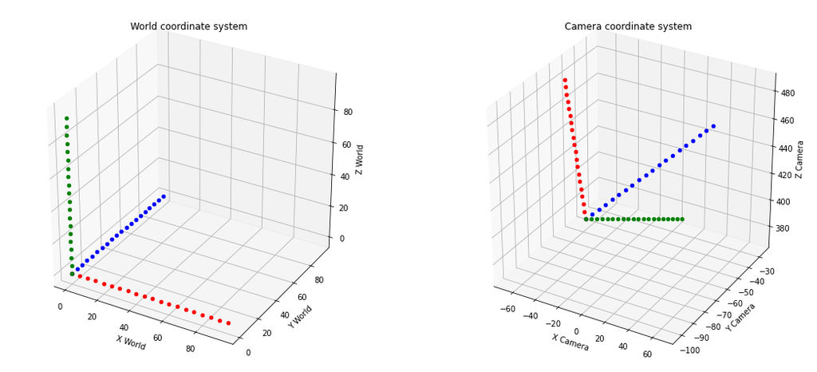

```python
# The code below was used for debuging. A visualization of how point in world
# coordinate system are projected to camera coordinate system

axis_test_x = np.array([ [i*5, 0, 0] for i in range(20) ])
axis_test_y = np.array([ [0, i*5, 0] for i in range(20) ])
axis_test_z = np.array([ [0, 0, i*5] for i in range(20) ])

fig = plt.figure()
fig.set_size_inches(18.5, 8.5)
ax1 = fig.add_subplot(121, projection='3d')
ax2 = fig.add_subplot(122, projection='3d')

for i in range(len(axis_test_x)):
    src = axis_test_x[i]
    trg = svdCalibration.to_camera_ref(axis_test_x[i])
    ax2.scatter(trg[0], trg[1], trg[2], color='r')
    ax1.scatter(src[0], src[1], src[2], color='r')

for i in range(len(axis_test_y)):
    src = axis_test_y[i]
    trg = svdCalibration.to_camera_ref(axis_test_y[i])
    ax2.scatter(trg[0], trg[1], trg[2], color='b')
    ax1.scatter(src[0], src[1], src[2], color='b')

for i in range(len(axis_test_z)):
    src = axis_test_z[i]
    trg = svdCalibration.to_camera_ref(axis_test_z[i])
    ax2.scatter(trg[0], trg[1], trg[2], color='g')
    ax1.scatter(src[0], src[1], src[2], color='g')

ax1.set_title('World coordinate system')
ax1.set_xlabel('X World')
ax1.set_ylabel('Y World')
ax1.set_zlabel('Z World')

ax2.set_title('Camera coordinate system')
ax2.set_xlabel('X Camera')
ax2.set_ylabel('Y Camera')
ax2.set_zlabel('Z Camera')

plt.show()
```